## Reproducible Research Peer Assessment 1

### Libraries used

```r
library(lubridate)
library(sqldf)
library(dplyr)
library(lattice)
```

### Loading and cleaning data

The code below is used to first download the file from the website and a temporary sace is created and unlinked after the download is complete. Formats are then changed to make the date column usable for further analysis.

```r
setwd("~/RWorkspace")

#Create a temp space for ZIP file
temp<-tempfile()
fileUrl<-"http://d396qusza40orc.cloudfront.net/repdata%2Fdata%2Factivity.zip"
download.file(fileUrl,temp)
ACT <- read.csv(unzip(temp, "activity.csv"),header = TRUE, sep = ",")
unlink(temp)

## Change Colclasses to date
ACT2<-ACT
ACT2[,2]<-as.Date(ACT2[,2])
```

### What is mean total number of steps taken per day?

1. First dataframe is aggregated to right level of granularity required to answer the question
2. Then a histogram is created
3. Then the mean and median is calculated using the codes below

```r
ACT3<-sqldf("select date, sum(steps) as steps from ACT2 group by date")
```

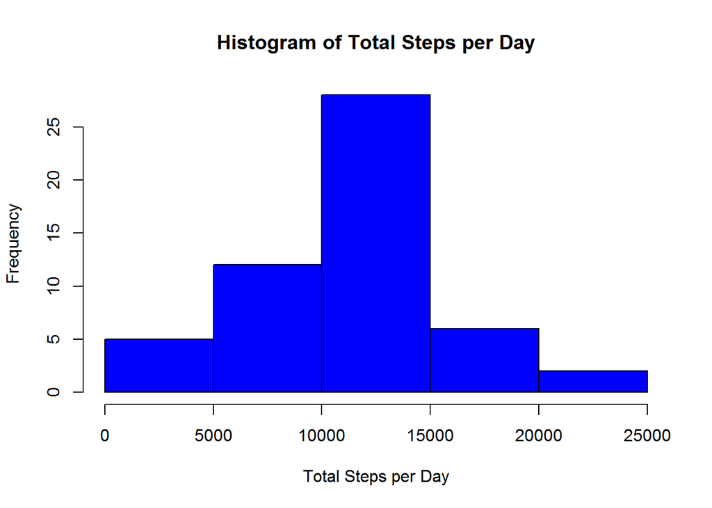

```r
#Histogram is created based on the summarised data above
hist(ACT3$steps,col="blue",
     main="Histogram of Total Steps per Day",
     xlab="Total Steps per Day")
```

```r
mean(ACT3$steps, na.rm = TRUE)
```

```
## [1] 10766.19
```

```r
median(ACT3$steps, na.rm = TRUE)
```

```
## [1] 10765
```

### What is the average daily activity pattern?

1. Make a time series plot (i.e. type = “l”) of the 5-minute interval (x-axis) and the average number of steps taken, averaged across all days (y-axis)
2. Which 5-minute interval, on average across all the days in the dataset, contains the maximum number of steps?

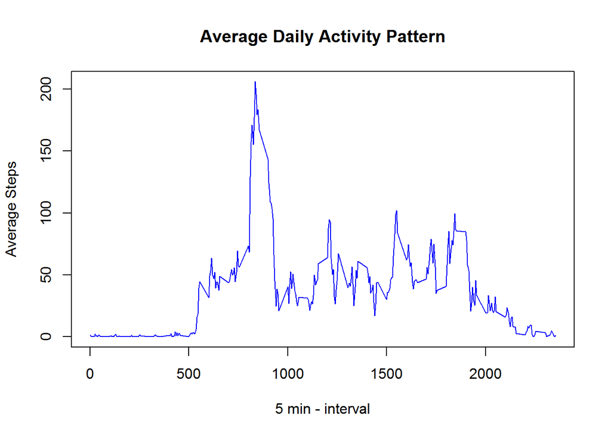

```r
newdata <- aggregate( steps~interval, data = ACT2, FUN = mean)
with( newdata, plot(interval,steps,
                    type="l",
                    col="blue",
                    main="Average Daily Activity Pattern",
                    xlab="5 min - interval",
                    ylab="Average Steps"))
```

```r
#calculate which interval has the maximim number of steps
with(newdata,interval[which.max(steps)])
```

```
## [1] 835
```

### Imputing missing values

1. Calculate and report the total number of missing values in the dataset (i.e. the total number of rows with NAs)
2. Devise a strategy for filling in all of the missing values in the dataset. The strategy does not need to be sophisticated. For example, you could use the mean/median for that day, or the mean for that 5-minute interval, etc.
3. Create a new dataset that is equal to the original dataset but with the missing data filled in.
4. Make a histogram of the total number of steps taken each day and Calculate and report the mean and median total number of steps taken per day. Do these values differ from the estimates from the first part of the assignment? What is the impact of imputing missing data on the estimates of the total daily number of steps?

```r
# get rows with NA's
df_NA <- ACT2[!complete.cases(ACT2),]

# number of rows
nrow(df_NA)
```

```
## [1] 2304
```

The number of rows with NAs is **2304**

```r
# change colname
colnames(newdata)[2]<-c("StepsInterval")

newdata<- inner_join(ACT2, newdata) %>% # every row will contain the average steps for the interval StepsInterval from newdata
    mutate(steps=ifelse(is.na(steps),StepsInterval,steps)) %>%
    select(-StepsInterval) # this will drop the StepsInterval from the dataframe
```

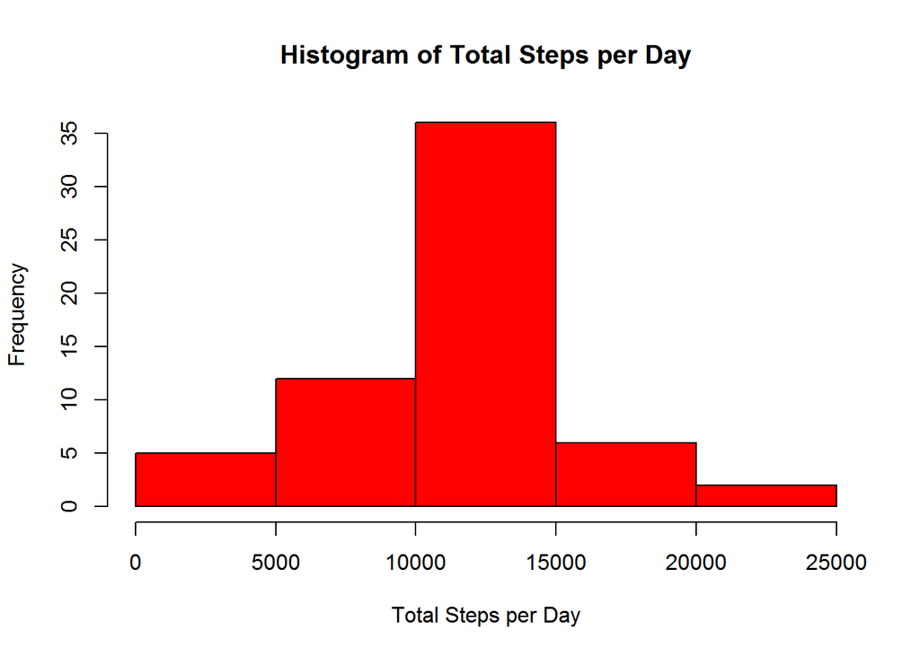

```r
# summarise and plot data
newdata1 <- newdata %>% group_by(date) %>% summarise(dailyTotal=sum(steps))

hist(newdata1$dailyTotal,
     col="red",
     main="Histogram of Total Steps per Day",
     xlab="Total Steps per Day")
```

```r
#calculate mean and median
mean(newdata1$dailyTotal)
```

```
## [1] 10766.19
```

```r
median(newdata1$dailyTotal)
```

```
## [1] 10766.19
```

### Are there differences in activity patterns between weekdays and weekends?

using lattice plotting system, lets compare weekend and weekday activity to identify any differences in activity

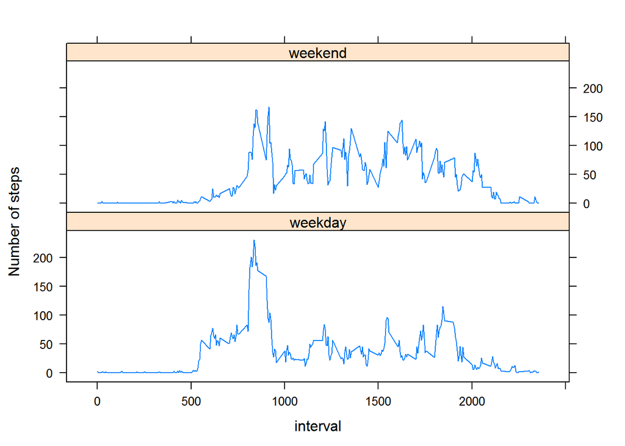

```r
newdata<-newdata %>%
    mutate(day=as.factor(ifelse(wday(date) %in% c(1,7),"weekend","weekday")))

#calculate mean of steps grouped by day and interval in 'newdata' dataset
newdata<- newdata %>% group_by(day,interval) %>% summarise(meansteps=mean(steps))
with (newdata, xyplot(meansteps ~ interval|day, type="l", ylab="Number of steps",layout=c(1,2)))
```

It can therefore be seen that the weekdays activities are more concentrated while weekend activities are more spread out.